# Barbell Lift Performance

DataScienceGB

19/09/2015

## Introduction

Using devices such as Jawbone Up, Nike FuelBand, and Fitbit it is now possible to collect a large amount of data about personal activity relatively inexpensively. One thing that people regularly do is quantify how much of a particular activity they do, but they rarely quantify how well they do it. The goal will be to use data from accelerometers on the belt, forearm, arm, and dumbell of 6 participants. They were asked to perform barbell lifts correctly and incorrectly in 5 different ways: A According to specification B Throwing elbows to the front C Lifting the dumbell only half the way D Lowering the dumbell only half the way E Throwing the hips to the front.

More information is available from the website here: [link] (http://groupware.les.inf.puc-rio.br/har). You can check out the pdf related to the test in the following link: [link] http://groupware.les.inf.puc-rio.br/public/papers/2013.Velloso.QAR-WLE.pdf

The training data for this project are available here: [link] (https://d396qusza40orc.cloudfront.net/predmachlearn/pml-training.csv) The test data are available here: [link] (https://d396qusza40orc.cloudfront.net/predmachlearn/pml-testing.csv)

## Model Buidling

We’ll first start loading the data directly from the source and loading main libraries for the process (caret and doMC), since processing this model had been a CPU bound process we’ll use the doMC package to split the work among 4 threads.

```r
library(caret)
library(doMC)
```

```r
registerDoMC(cores = 4)
set.seed(5150)

trainingOri=read.csv("http://d396qusza40orc.cloudfront.net/predmachlearn/pml-training.csv",na.strings=c("","NA","#DIV/0!"))
testingOri=read.csv("http://d396qusza40orc.cloudfront.net/predmachlearn/pml-testing.csv",na.strings=c("","NA","#DIV/0!"))

dim(testingOri)
```

```
## [1]  20 160
```

```r
dim(trainingOri)
```

```
## [1] 19622   160
```

```r
library(caret)
library(doMC)
#Setting number of parallel process to 4
registerDoMC(cores = 4)
```

We now start by splitting our training data into a training and a test set

```r
inTrain<-createDataPartition(y=trainingOri$classe,p=.75,list=F)

testingFinal=testingOri
training=trainingOri[inTrain,]
testing=trainingOri[-inTrain,]
```

Now we’re going to clean up our data by removing useless columns from our sets: we’ll select only columns having more than 90% of no NA values and remove the first seven columns that holds data that have no value for the model, such as participant name and time stamps.

```r
#COUNT NA VALUES
notna_count2 <-sapply(training, function(y) sum(length(which(!is.na(y)))))
notna_count2=data.frame(notna_count2)
#SELECT ONLY COLUMNS WITH MORE THAN 90% VALID VALUES
cutoff=round(dim(training)[1]*.9)
training=training[,notna_count2$notna_count2>=cutoff]
testing=testing[,notna_count2$notna_count2>=cutoff]
testingFinal=testingFinal[,notna_count2$notna_count2>=cutoff]

#REMOVE DATA AND TIME COLUMNS
training=training[,-(1:7)]
testing=testing[,-(1:7)]
testingFinal=testingFinal[,-(1:7)]
```

Now we’ll use some caret features to find Near Zero Variables, Linear Combos and High Correlated variables. We’ll remove any of these variables from our model, we’ll be using an 80% correlation value as a cut off.

```r
library(knitr)
trainNZV = nearZeroVar(training, saveMetrics=TRUE)
kable(head(trainNZV,5))
```

|  | freqRatio | percentUnique | zeroVar | nzv |
| --- | --- | --- | --- | --- |
| roll_belt | 1.083090 | 7.7456176 | FALSE | FALSE |
| pitch_belt | 1.133803 | 11.6184264 | FALSE | FALSE |
| yaw_belt | 1.020942 | 12.4609322 | FALSE | FALSE |
| total_accel_belt | 1.057655 | 0.1970376 | FALSE | FALSE |
| gyros_belt_x | 1.047151 | 0.9104498 | FALSE | FALSE |

```r
comboinfo = findLinearCombos(training[,-53])
comboinfo
```

```
## $linearCombos
## list()
##
## $remove
## NULL
```

Previous functions (nearZeroVar and findLinearCombos) doesn’t show any variables to cut out from our model. Now lets look for highly correlated predicates (aka >. 80)

```r
trainCorr = cor(training[,-53])
highCorr  = findCorrelation(trainCorr, 0.80)
training  = training[, -highCorr]
testing   =  testing[, -highCorr]
testingFinal = testingFinal[,-highCorr]
dim(training)[2]
```

```
## [1] 40
```

```r
dim(trainingOri)[2]
```

```
## [1] 160
```

As you can see from the output of dim command, we stated with 160 variables and now we are working with 40.

Now we’ll try two different models: boosted trees (gbm) and random forest (rf), and then select the more accurate model to run the final test. We’ll run this tests using a Cross Validation technique: creating differnt splits of data to train and test against the main test data.

```r
#Subset training
selector=round(runif(dim(training)[1])*3,0)
training$selector=selector
training0=subset(training,training$selector==0)
training1=subset(training,training$selector==1)
training2=subset(training,training$selector==2)
training3=subset(training,training$selector==3)

#remove selector
training0=training0[,-41]
training1=training1[,-41]
training2=training2[,-41]
training3=training3[,-41]
training=training[,-41]
```

Following we’ll run the Boosted Trees models. For the purpose of this document we’ll only run slice number 2, wich in our tests shows the higher accuracy for both models, we’ll show the other runs as comments.

```r
#modFitgbm0<-train(classe~.,data=training0,method="gbm",verbose=F)
#modFitgbm1<-train(classe~.,data=training1,method="gbm",verbose=F)
modFitgbm2<-train(classe~.,data=training2,method="gbm",verbose=F)
```

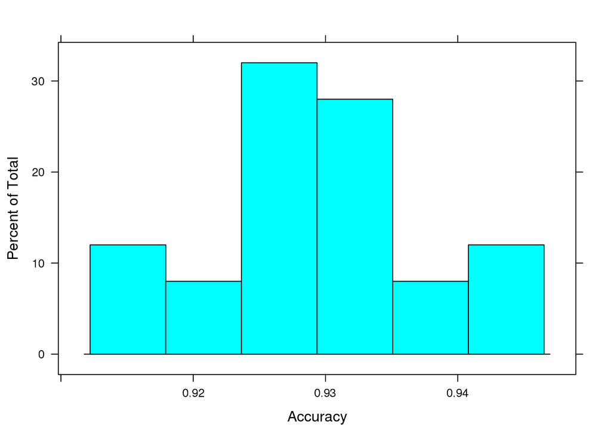

```r
#modFitgbm3<-train(classe~.,data=training3,method="gbm",verbose=F)

#predgbm0=predict(modFitgbm0,newdata=testing)
#predgbm1=predict(modFitgbm1,newdata=testing)
predgbm2=predict(modFitgbm2,newdata=testing)
#predgbm3=predict(modFitgbm3,newdata=testing)

#Obtain Confussion Matrix for each model
#cMgbm0=confusionMatrix(predgbm0,testing$classe)
#cMgbm1=confusionMatrix(predgbm1,testing$classe)
cMgbm2=confusionMatrix(predgbm2,testing$classe)
#cMgbm3=confusionMatrix(predgbm3,testing$classe)

gbm2Accuracy=cMgbm2$overall["Accuracy"]

histogram(modFitgbm2)
```

Now lets run the Random Forests models, we’ll also run slice number 2, to have the models be compared in the same terms.

```r
#modFitRf0<-train(classe~.,data=training0,method="rf")
#modFitRf1<-train(classe~.,data=training1,method="rf")
modFitRf2<-train(classe~.,data=training2,method="rf")
```

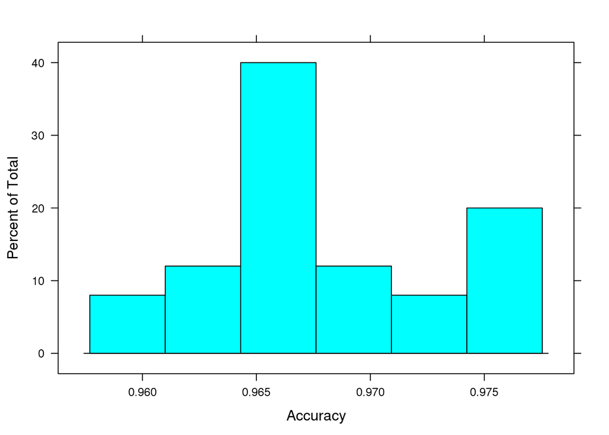

```r
#modFitRf3<-train(classe~.,data=training3,method="rf")
#predrf0=predict(modFitRf0,newdata=testing)
#predrf1=predict(modFitRf1,newdata=testing)
predrf2=predict(modFitRf2,newdata=testing)
#predrf3=predict(modFitRf3,newdata=testing)

#Obtain Confussin Matrix for models

#cMrf0=confusionMatrix(predrf0,testing$classe)
#cMrf1=confusionMatrix(predrf1,testing$classe)
cMrf2=confusionMatrix(predrf2,testing$classe)
#cMrf3=confusionMatrix(predrf3,testing$classe)

rf2Accuracy=cMrf2$overall["Accuracy"]
histogram(modFitRf2)
```

After running a Cross Validation between Boosted Trees and Random Forest models, the second one always shown higher accuracy in each of the slices we tested. For instance, in the particular slice that we use gmb model has a **0.9404568** accuracy value, while rf model has a **0.9794046** For this reason we’ll be using the Random Forest algorithm to create a model using the full training set, we’ll use this as the final model against the 20 cases test set.

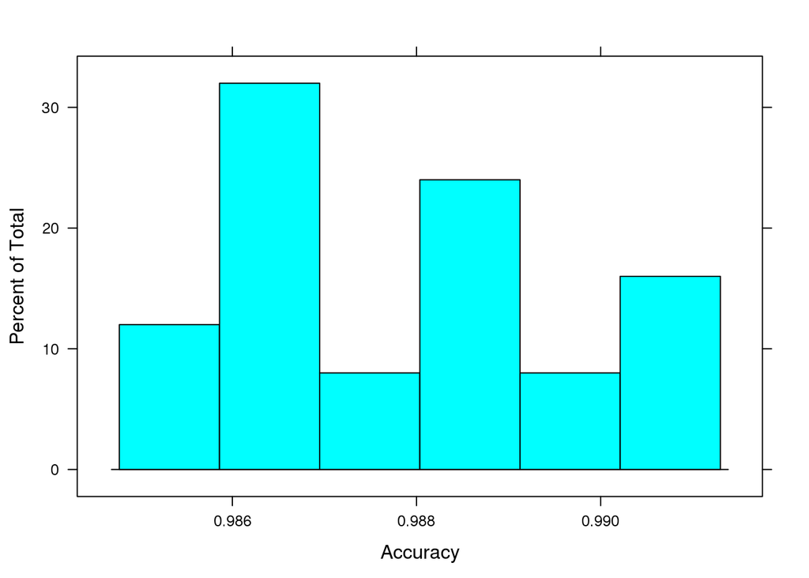

```r
modFitRf<-train(classe~.,data=training,method="rf")
predrf=predict(modFitRf,newdata=testing)

#Obtain Confussion Matrix for models
cMrf=confusionMatrix(predrf,testing$classe)

rfAccuracy=cMrf$overall["Accuracy"]
histogram(modFitRf)
```

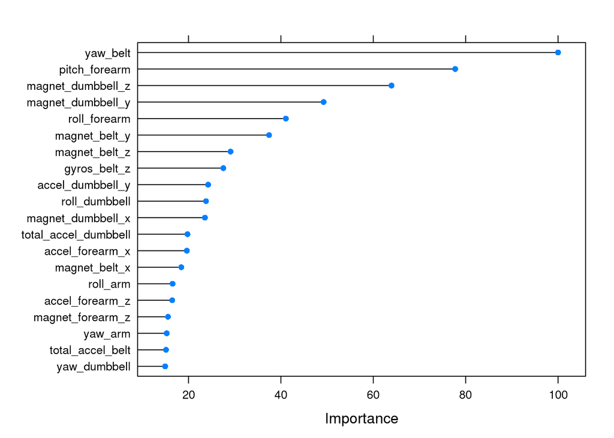

```r
plot(varImp(modFitRf),top=20)
```

## Conclusion

Final model accuracy is **0.9924551**, which is the higher for all the models tested. Lets test it against the original testing set:

```r
predrffinal=predict(modFitRf,testingFinal)
```

Having done this, our answers ready for submmiting are: **B, A, B, A, A, E, D, B, A, A, B, C, B, A, E, E, A, B, B, B**